# Basic neural networks in R

Today, we are going to look at my custom implementation of the back-propagation algorithm in R. In total, it is under 60 lines of code, but does require a bit of thought to understand a few complex steps. In order to make this relatively fast, I have vectorized the mini-batches. That means that it will be significantly faster to calculate a single epoch when the mini-batch size is large (though the progress in one epoch will be diminished if the number is too big).

## Implementation

I start by constructing a neural network object, that is built by passing a vector giving the sizes of each layer of the neural network. Notice that this vector needs to include the input and output layer (so the minimum length for a non-trival network is three). This object contains everything that describes the architecture of the network: weights, biases, the cost function, the activation function, and the derivatives of both. There are not weights or biases associated with the output layer, but to keep the code clean, I add an empty element to the end of the weight and bias lists.

```r
nnetObj <- function(sizes) {
  f <- function(n,m) matrix(rnorm(n*m),ncol=m)
  structure(list(sizes = sizes,
                 nlayer = length(sizes),
                 sigFun = function(v) 1 / (1 + exp(-v)),
                 sigFunDeriv = function(v) (1 / (1 + exp(-v))) * (1 / (1 + exp(v-1))),
                 cost = function(a, y) 0.5 * apply((a - y)^2,2,sum),
                 costDeriv = function(a, y) (a - y),
                 w = mapply(f, c(sizes[-1],0), c(sizes[-length(sizes)],0), SIMPLIFY=FALSE),
                 b = lapply(c(sizes[-1],0), rnorm)),class="net")
}
```

We now need a function that takes a neural network and a matrix of input data and returns a list of the weighted inputs and activation functions for the current set of weights and biases in the network. This is done by iteratively applying the weights and biases on the input in one layer to get the activations for the next layer. Notice that there is an activation for every layer, but no weighted input for the input layer (as before, we add an empty element to z to keep the notation consistent).

```r
feedforward <- function(nn, x) {
  a <- list(thisA <- t(x))
  z <- list(structure(numeric(0), .Dim = c(0L, 0L)))

  for (k in 1:(nn$nlayer-1)) {
    z <- append(z, list(thisZ <- nn$w[[k]] %*% thisA + nn$b[[k]]))
    a <- append(a, list(thisA <- nn$sigFun(thisZ)))
  }

  structure(list(z=z, activations=a),class="ff")
}
```

Now, we write a function that takes a neural network and the results of the feedforward step to learn the errors (delta in my notes) for every layer of the network. There is no error rate for the input layer, but again we add an empty element as a placeholder. These are calculated by looping backwards through the layers and applying our formula relating the errors in one layer to the next layer.

```r
backprop <- function(nn, ff, y) {

  delta <- vector("list", length(nn$w))
  delta[[1]] <- structure(numeric(0), .Dim = c(0L, 0L))

  delta[[nn$nlayer]] <- nn$costDeriv(ff$a[[nn$nlayer]], t(y)) * nn$sigFunDeriv(ff$z[[nn$nlayer]])
  for (l in (nn$nlayer-1):2) {
    delta[[l]] <- t(nn$w[[l]]) %*% delta[[l+1]] * nn$sigFunDeriv(ff$z[[l]])
  }

  delta
}
```

Finally, I wrap all of this into a function that encodes the stochastic gradient descent algorithm. It optionally accepts a test set, for which predictions are computed and error rates displayed, at the end of the each epoch. The tuning parameters are the size of the mini-batch, the number of epochs, and the learning rate. We have to construct a neural network architecture to input to this function, and we get a copy of the network back, with the updated weights and biases.

```r
sgd <- function(nn, x, y, xtest = NULL, ytest = NULL, m=1, epochs=10L, eta=1.0, verbose=TRUE) {
  n <- nrow(x)
  y <- as.matrix(y)

  for (e in 1:epochs) {
    # sample a set of mini-batches for the data
    id <- sample(rep(1:(n/m),length.out=n))
    mb <- split(1:n, id)

    for (j in 1:length(mb)) {
      mt <- length(mb[[j]])

      # get activation (a), weighted input (z) and errors (delta)
      # from forward & backward passes through the network
      ff <- feedforward(nn, x[mb[[j]],,drop=FALSE])
      delta <- backprop(nn, ff, y[mb[[j]],,drop=FALSE])

      # calculate derivatives of biases and weights
      nablaB <- lapply(delta, function(v) apply(v, 1, mean))
      nablaW <- mapply(function(u,v) u %*% t(v) / mt, delta[-1], ff$a[-nn$nlayer], SIMPLIFY=FALSE)

      # update biases and weights
      nn$b[-nn$nlayer] <- mapply(function(u,v) u - v * eta, nn$b[-nn$nlayer], nablaB[-1])
      nn$w[-nn$nlayer] <- mapply(function(u,v) u - v * eta, nn$w[-nn$nlayer], nablaW)
    }
    if (!is.null(xtest) & verbose) {
      yhat <- feedforward(nn, x)$a[[nn$nlayer]]
      trainError <- signif(mean(nn$cost(yhat, as.numeric(y))),4)
      yhat <- feedforward(nn, xtest)$a[[nn$nlayer]]
      testError <- signif(mean(nn$cost(yhat, as.numeric(ytest))),4)
      testMisClass <- signif(mean( (yhat > 0.5) != (Ytest) ),4)
      cat(sprintf("Epoch %04d/%04d:   train cost - %f  test cost - %f  test miss. rate - %f\n",
        e, epochs, trainError, testError, testMisClass))
    }
  }

  nn
}
```

Personally, this algorithm is fairly straightforward once you get the data structure for the network settled. The hardest part is making sure that the algorithm works correctly in vectorized form. The formula for *nablaW*, while simple in its final form, took a bit of head scratching to work out (it turns out the dot product conveniently does the right thing with multiple inputs by summing over them). **However, this is still a bug this current implementation for networks with more than one output. I am working on debugging it, and will update this when I have.**.

## Application to MNIST

Now, I want to read in the full complete version of the MNIST dataset. Notice that the images are larger and the number of samples are significantly increased.

```r
train <- read.csv("../../../class_data/mnist/mnist_train.csv", as.is=TRUE, header=FALSE)
test <- read.csv("../../../class_data/mnist/mnist_test.csv", as.is=TRUE, header=FALSE)
dim(train)
```

```
## [1] 60000   785
```

```r
dim(test)
```

```
## [1] 10000   785
```

To simplify things (and because my multi-output code is still buggy), we are just going to solve the subproblem of differentiating between the digits 3 and 5. If you recall, this was one of the hardest parts of the original problem.

```r
set.seed(1)
trainIndex <- which(train[,1] %in% c(3,5))
testIndex <- which(test[,1] %in% c(3,5))

Xtrain <- train[trainIndex,-1]
Xtest  <- test[testIndex,-1]
Ytrain <- as.numeric(train[trainIndex,1] == 5)
Ytest <- as.numeric(test[testIndex,1] == 5)
```

We can now run a simple neural network with one hidden layer with 5 neurons. I’ll start by just building the architecture of the neural network:

```r
nn <- nnetObj(sizes <- c(784,5,1))
```

Do the dimensions of the output seem to make sense?

```r
lapply(nn$w, dim)
```

```
## [[1]]
## [1]   5 784
##
## [[2]]
## [1] 1 5
##
## [[3]]
## [1] 0 0
```

```r
lapply(nn$b, length)
```

```
## [[1]]
## [1] 5
##
## [[2]]
## [1] 1
##
## [[3]]
## [1] 0
```

Now, let’s train this over 10 epochs with a learning rate of 1 and mini-batch size of 100.

```r
nn2 <- sgd(nn, Xtrain, Ytrain, Xtest, Ytest, m=100, epochs=10, eta=1)
```

[output not shown]

```r
nn2 <- sgd(nn, Xtrain, Ytrain, Xtest, Ytest, m=100, epochs=10, eta=0.1)
```

[output not shown]

What about increasing the number of hidden nodes?

```r
set.seed(1)
nn <- nnetObj(sizes <- c(784,25,1))
nn2 <- sgd(nn, Xtrain, Ytrain, Xtest, Ytest, m=100, epochs=10, eta=0.5)
```

[output not shown]

```r
set.seed(1)
nn <- nnetObj(sizes <- c(784,200,1))
nn2 <- sgd(nn, Xtrain, Ytrain, Xtest, Ytest, m=100, epochs=25, eta=0.5)
```

[output not shown]

Now, what happens if we further increase the number of layers, adding a second layer with 50 hidden nodes.

```r
set.seed(1)
nn <- nnetObj(sizes <- c(784,200,50,1))
nn2 <- sgd(nn, Xtrain, Ytrain, Xtest, Ytest, m=100, epochs=25, eta=0.3)
```

[output not shown]

```r
yhat <- feedforward(nn2, Xtest)$a[[nn$nlayer]]
```

Another thing missing from seeing this as a per-computed html page is how long these algorithms are taking. Here are timing of how long it takes to fit one epoch for 10 hidden nodes versus 20 hidden nodes, for a variety of mini-batch sizes.

```r
nn <- nnetObj(sizes <- c(784,10,1))
system.time({nn2 <- sgd(nn, Xtrain, Ytrain, Xtest, Ytest, m=10, 1, 0.5, FALSE)})
```

```
##    user  system elapsed
##  11.328   0.180  11.546
```

```r
system.time({nn2 <- sgd(nn, Xtrain, Ytrain, Xtest, Ytest, m=100, 1, 0.5, FALSE)})
```

```
##    user  system elapsed
##   1.446   0.055   1.486
```

```r
system.time({nn2 <- sgd(nn, Xtrain, Ytrain, Xtest, Ytest, m=1000, 1, 0.5, FALSE)})
```

```
##    user  system elapsed
##   0.409   0.069   0.417
```

```r
nn <- nnetObj(sizes <- c(784,20,1))
system.time({nn2 <- sgd(nn, Xtrain, Ytrain, Xtest, Ytest, m=10, 1, 0.5, FALSE)})
```

```
##    user  system elapsed
##  11.226   0.145  11.334
```

```r
system.time({nn2 <- sgd(nn, Xtrain, Ytrain, Xtest, Ytest, m=100, 1, 0.5, FALSE)})
```

```
##    user  system elapsed
##   1.485   0.049   1.501
```

```r
system.time({nn2 <- sgd(nn, Xtrain, Ytrain, Xtest, Ytest, m=1000, 1, 0.5, FALSE)})
```

```
##    user  system elapsed
##   0.430   0.078   0.433
```

Notice that the scaling in the number of weights and mini-batch sizes are atypical of a lower-level programming language. We see almost no slowdown in increasing the number of nodes and a drastic speed-up in increasing the mini-batch size. This has to do with the most of the computation time occurring in R rather than the actual multiplication and allocation of matrices. In highly optimized implementations, you would see some decrease in the mini-batch size up to a critical point (having the do with caches and other details of the CPU or GPU architecture), at which point there would be virtually no speed up. The relationship to the size of the network is a complex one that we will explore later.

### Visualizing the output of a neural network

While often opaque, we can sometimes benefit from actually trying to understand the learned weights in a fitted neural network. Running a small model with a single layer of just 9 hidden nodes, we can plot the associated weights of each of the nodes:

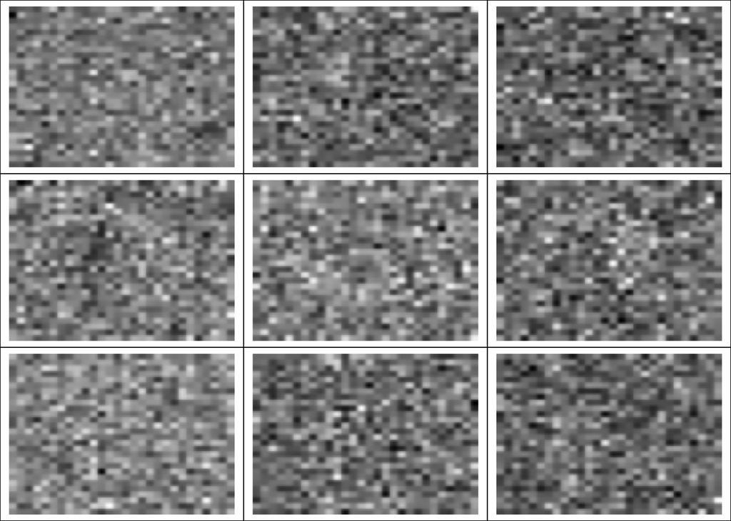

```r
nn <- nnetObj(sizes <- c(784,9,1))
nn2 <- sgd(nn, Xtrain, Ytrain, Xtest, Ytest, m=100, epochs=25, eta=0.2, FALSE)

par(mfrow=c(3,3))
par(mar=c(0,0,0,0))
for (j in 1:9) {
  z <- nn2$w[[1]][j,]
  z <- (z - min(z)) / (max(z) - min(z))
  z <- matrix(as.matrix(z),28,28,byrow=TRUE)
  plot(0,0,axes=FALSE,xlab="",ylab="",main="")
  rasterImage((1 - z),-1,-1,1,1)
  box()
}
```

These can be interpreted as a filter on the image. Here, it is difficult to make much of the filters, but in future problems we can actually interpret what meta-features are getting selected in each node.

### Misclassified points

As with our SVM implementation, we can attempt to understand where the neural network is having the most difficulty by pulling out mis-classified examples from the test set.

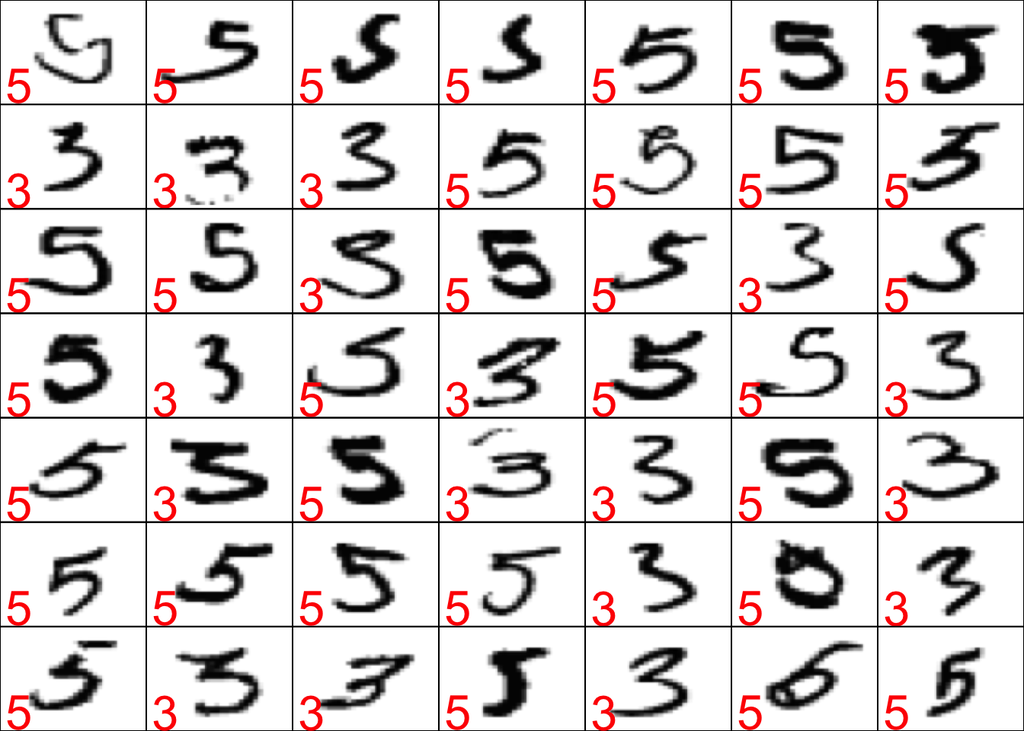

```r
iset <- order((yhat - Ytest)^2, decreasing=TRUE)[1:(7*7)]
par(mar=c(0,0,0,0))
par(mfrow=c(7,7))
for (j in iset) {
  y <- matrix(as.matrix(Xtest[j,]),28,28,byrow=TRUE)
  y <- (1 - y / 256)

  plot(0,0,xlab="",ylab="",axes=FALSE)
  rasterImage(y,-1,-1,1,1)
  box()
  text(-0.8,-0.7, c(3,5)[Ytest[j]+1], cex=3, col="red")
}
```

Most of these seem classifiable by us, though some are understandably difficult given the squished versions of the digits. In order to improve on this model, we need to build bigger, and deeper networks. To do that, we need to make some small tweaks to our algorithm in order to fit the weights and biases in a more stable and accurate way.